# Evaluating collider issues arising from ascertainment in large population biobanks

Gibran Hemani

2020-03-22

Population of 50M people. Recruiting 5 million to participate, likely will have some ascertainment for high SES, high education, high health. Further ascertainment bias could arise due to incomplete questionnaire data etc.

What is the impact on interpretability of genetic studies?

- Does the problem of ascertainment shrink as larger proportion of the population gets included?
- What matters?
  - Effects on SES
  - Extent of ascertainment

Initial results for the situation of

```
a -> ses <- b
```

```r
suppressWarnings(suppressPackageStartupMessages({
    library(knitr)
    library(ggplot2)
    library(dplyr)
}))
load("../results/ascertainment.rdata")
```

How sample mean of SES changes with proportion of population sampled

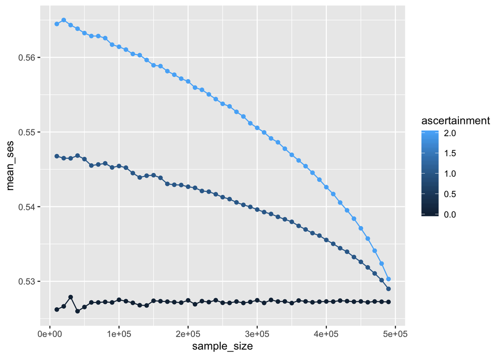

```r
ggplot(param, aes(x=sample_size, y=mean_ses)) +
geom_point(aes(colour=ascertainment)) +
geom_line(aes(colour=ascertainment, group=as.factor(ascertainment)))
```

How collider-induced correlation between `a` and `b` changes with proportion of population sampled

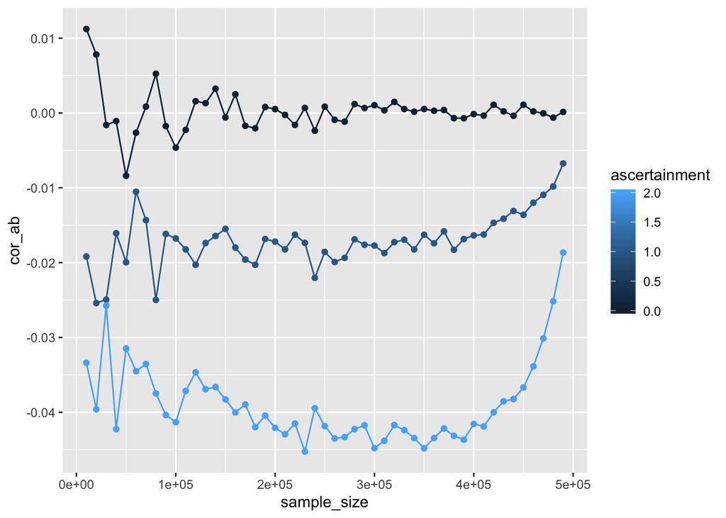

```r
ggplot(param, aes(x=sample_size, y=cor_ab)) +
geom_point(aes(colour=ascertainment)) +
geom_line(aes(colour=ascertainment, group=as.factor(ascertainment)))
```

How p-value between `a` and `b` changes

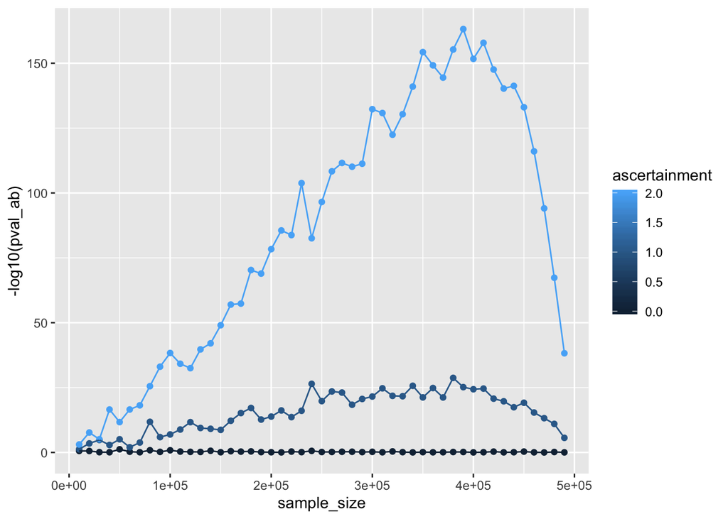

```r
ggplot(param, aes(x=sample_size, y=-log10(pval_ab))) +
geom_point(aes(colour=ascertainment)) +
geom_line(aes(colour=ascertainment, group=as.factor(ascertainment)))
```

How effect size between `a` and `b` changes

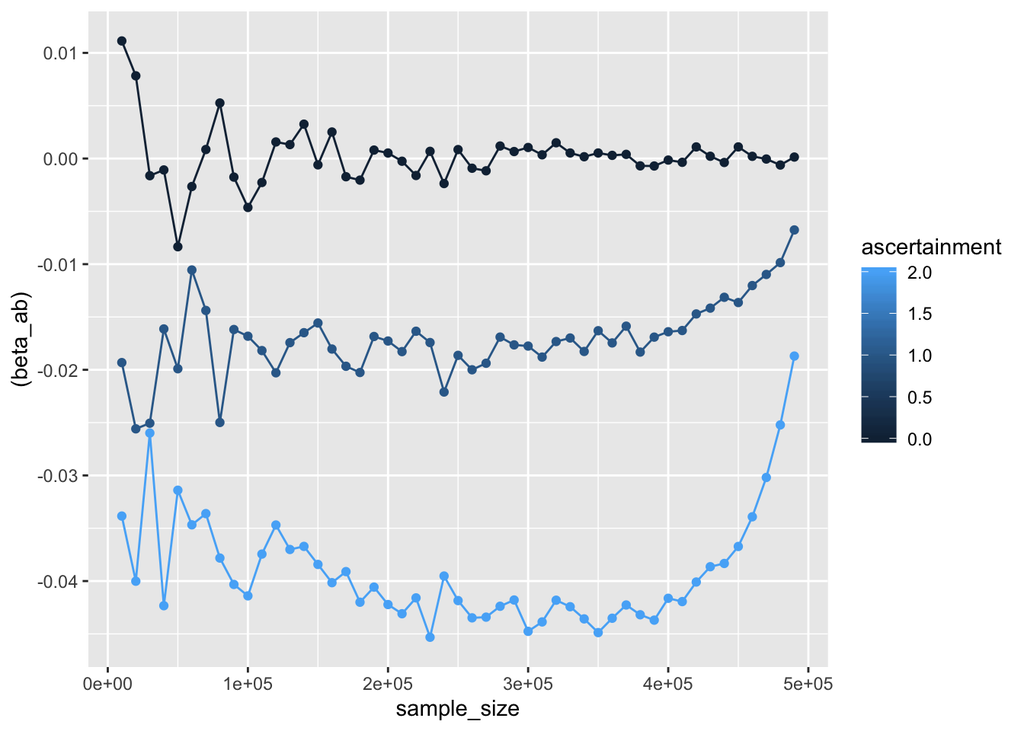

```r
ggplot(param, aes(x=sample_size, y=(beta_ab))) +
geom_point(aes(colour=ascertainment)) +
geom_line(aes(colour=ascertainment, group=as.factor(ascertainment)))
```

## Problems

1. What is the distribution of genetic effects for SES, assume it is highly polygenic and with a sample size of 5 million we get a lot of power
2. Sampling individuals is very slow when sample sizes are very large
3. Can we come up with a theoretical derivation instead of running simulations?